# MY474 Summative Assignment #2

February 2025

## 1. Scope and Data Wrangling

*Can we accurately predict individuals’ privatization of the environment over the economy by imputing them from other survey items?*

**What Social Scientists Need from Imputation:**

- Preservation of the distribution: Recovering both pro-environment and pro-economy responses in a balanced way, avoiding overfitting to the modal group, preserving minority responses
  - Binary outcome: balancing Recall (pro-environment) and Specificity (pro-economy)
  - Continuous outcome: stable MAE and RMSE across the full 0–10 response range

**Data Wrangling:**

- Preprocessing:
  - Encoded categorical vs numerical items; dropped high-cardinality factors and uninformative variables (i.e. serial ID)
  - Outcome recoded in 3 formats: Continous (0-10), binary (1-4 = 0, 5 = NA, 6-10 = 1) and Multiclass (0–3, 4–6, 7–10)
- Missing Data and Imputation:
  - Set “Don’t Know”/“Not stated” to NA; removed >90% missing or near-zero variance variables
  - Used Random Forest imputation (missRanger) for remaining missing predictors

## 2. Model Fitting Routine

- **Data Selection:**
  - Trained and validated models on the 2017 BES data only
  - Evaluated out-of-sample on 2019 BES respondents
  - Ensures temporal generalisation by testing on future (2019) respondents
- **Modelling:**
  - Evaluated 9 models: Regularised Regression, Random Forest and Gradient Boosted Trees (LightGBM) across 3 outcome types
- **Threshold Optimisation:**
  - Tuned Macro F1: giving equal weight to pro-environment and pro-economy classification

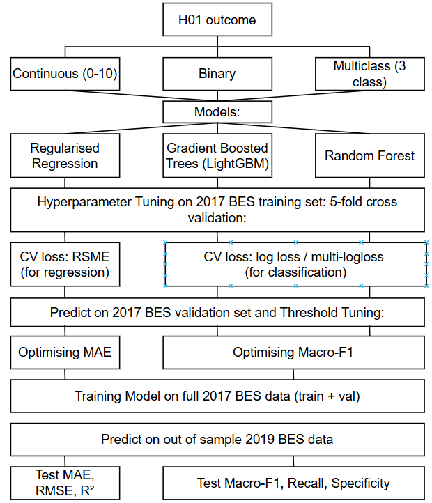

## 3. Key Results

- **Binary Models Perform Best Overall:**
  - LightGBM and Regularised Regression achieved highest Macro F1 scores (0.63, 0.62)
  - Pro-Environment views can be reliably imputed (Recall = 0.96), but pro-economy responses remain under-recovered (Specificity = 0.23–0.57)
- **Continuous Outcome Less Reliable:**
  - Best model (MAE = 1.75) shows unstable calibration across the 0-10 score range (see chart)
  - Low R² (0.16) and non-uniform predictive error undermines imputation consistency
- **Multiclass Models Show Imbalanced Performance:**
  - LightGBM achieved Macro F1 = 0.60, but per-class scores were highly imbalanced (Pro-economy class F1 = 0.12), limiting imputation accuracy for minority class

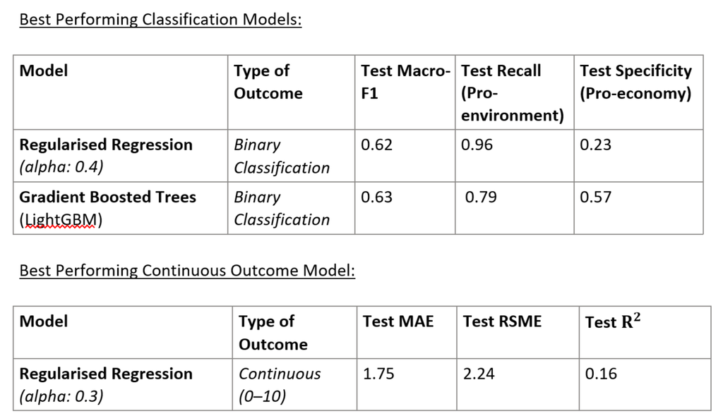

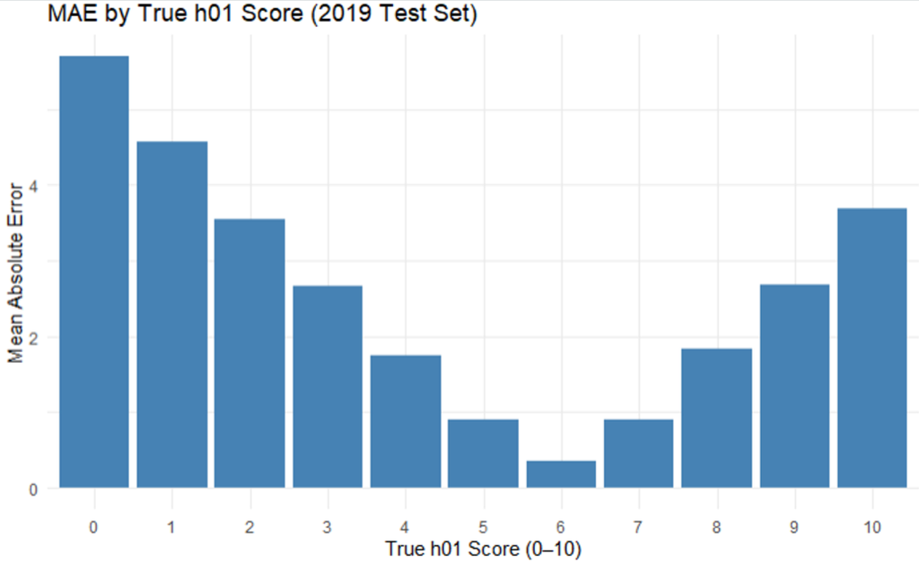

## 4. Implications and Limitations

*How many survey questions can be dropped while maintaining test performance?*

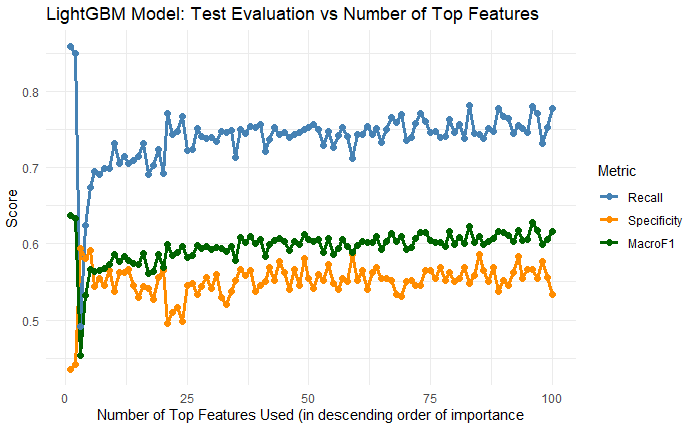

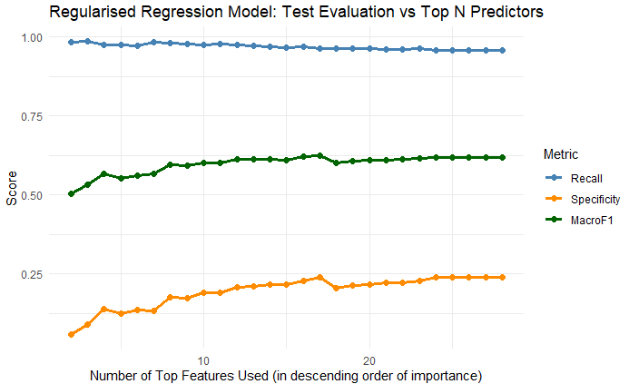